# User Guide: PLSandO

Maider Aguerralde Martin

2026-05-15

# Introduction

This guide provides a comprehensive walkthrough of the PLSandO tool, designed to handle standard Principal Component Analysis (PCA), Partial Least Squares (PLS), PLS Discriminant Analysis (PLS-DA), Multi-block structures (MBPCA, MBPLS and MBPLSDA), and multilevel cases. Developed by the BiostatOmics Lab, it is publicly available on the [BiostatOmics GitHub repository](https://github.com/BiostatOmics/PLSandO/).

Beyond model fitting, PLSandO incorporates a wide range of functionalities for data preprocessing, result exploration and interpretation, variable selection, and outlier detection, enabling a complete start-to-end analysis workflow from raw data to model evaluation and interpretation.

# Installation

Currently, the package can be directly installed from GitHub using the `devtools` R package by:

```r
install.packages("devtools")
devtools::install_github("BiostatOmics/PLSandO")
```

# PCA

We will use the classic `iris` dataset to demonstrate the basic workflow of PCA with PLSandO: Preprocessing -> Model Fitting -> Visualization.

## Data Preparation

PLSandO includes the `Preparing()` function, which handles the transformation of categorical variables for their inclusion in the different dimensionality reduction techniques available in PLSandO. In addition, it allows filtering of variables with near-zero variance and the exclusion of variables or observations with a high proportion of missing values.

Although `Preparing()` can be applied independently, it is internally integrated into the PCA workflow using conservative parameter settings aimed at preventing numerical or computational issues during model fitting. The internal preprocessing applies only minimal and extreme filters — such as the removal of variables with zero variance or the removal of variables with almost no available values — that would otherwise prevent the PCA algorithm from being properly computed.

In the following example, categorical variables are encoded for inclusion in multivariate models, variables with (near-)zero variance are removed, and variables or observations with a high proportion of missing values are excluded. The filtering thresholds shown here are intentionally conservative and are mainly intended to avoid numerical issues during PCA computation rather than to perform aggressive data cleaning.

As output, `Preparing()` also returns a concise summary describing the preprocessing steps applied and the modifications performed on the original dataset, allowing users to easily track how the data have been transformed.

```r
data("iris")

# Preprocess the data
x_prepared = Preparing(iris,includeFactors = TRUE, CVfilter = 0.00001, excludeNA = 0.2)
#Observe the modifies dataset
head(x_prepared$x)
```

```
##    Sepal.Length Sepal.Width Petal.Length Petal.Width Species_setosa
## r1          5.1         3.5          1.4         0.2              1
## r2          4.9         3.0          1.4         0.2              1
## r3          4.7         3.2          1.3         0.2              1
## r4          4.6         3.1          1.5         0.2              1
## r5          5.0         3.6          1.4         0.2              1
## r6          5.4         3.9          1.7         0.4              1
##    Species_versicolor Species_virginica
## r1                  0                 0
## r2                  0                 0
## r3                  0                 0
## r4                  0                 0
## r5                  0                 0
## r6                  0                 0
```

```r
#Observe the function modifications
x_prepared$removed
```

```
## $Variables
##       Variable    Model                                 Problem
## 1 Sepal.Length
## 2  Sepal.Width
## 3 Petal.Length
## 4  Petal.Width
## 5      Species Modified Factor type variable converted to dummy
##
## $Observations
## [1] Observation Problem
## <0 rows> (o 0- extensión row.names)
```

The output of `x_prepared$x` could be used to its introduction into `pca()`function. However, this conservative thresholds are already taken into account when running the `pca()`main function.

## Running PCA

A PCA model can easily be run by:

```r
mypca = pca(iris)
```

## Results Visualization

### Essential Visualization

The `pcaPlot()` function is a versatile wrapper for different plots for PCA results visualization.

First the code for visualizing a Scree Plot is introduced:

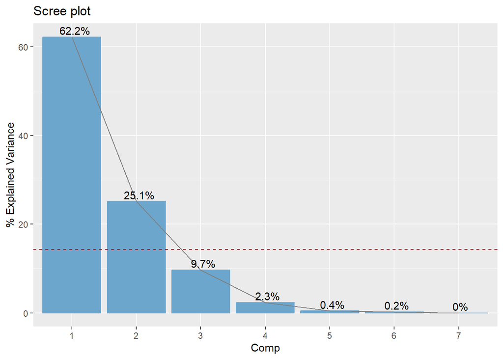

```r
# 1. Scree Plot: Check explained variance
pcaPlot(mypca, type = 'scree')
```

Then, the codes for the Score and Loading plots are introduced. In the Score plot, the observations will be colored by the Species variable including the 95% confidence ellipses. In the Loading plot, variables will be colored by their contribution (so the importance of the variable in the component). In both cases, first and second components will be shown.

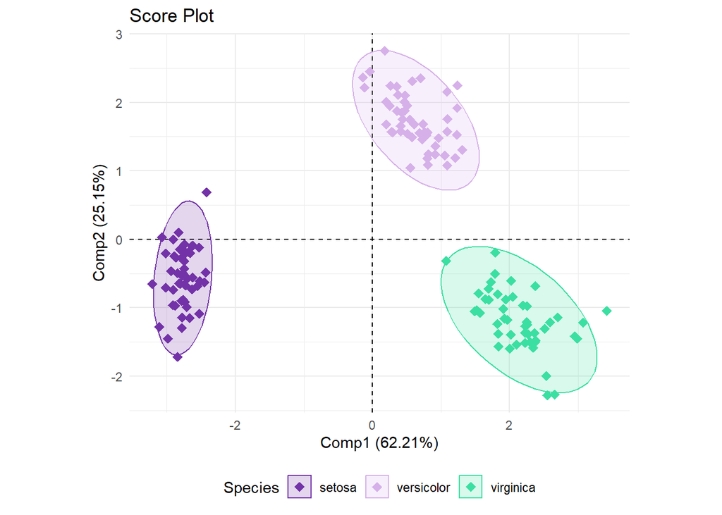

```r
# 2. Score Plot: Observations colored by Species
pcaPlot(mypca, type = 'scores', colBy = 'Species', labels = FALSE)
```

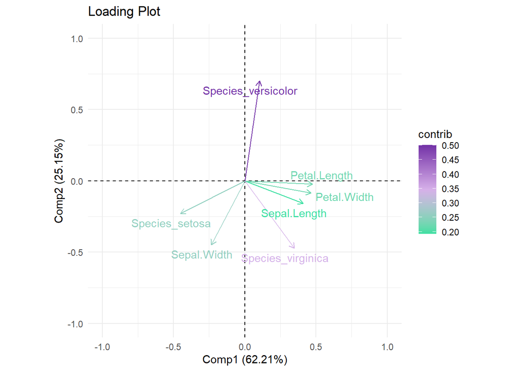

```r
# 3. Loadings Plot: Variable contributions
pcaPlot(mypca, type = 'loadings', shape = 'arrow', colBy = 'contrib', labels = TRUE)
```

Additionally, PLSandO includes the option to create biPlot which overlays the Score and Loading plots. It allows us to see the relationship between samples and variables simultaneously. For instance, you can identify which variables are responsible for a specific cluster of samples.

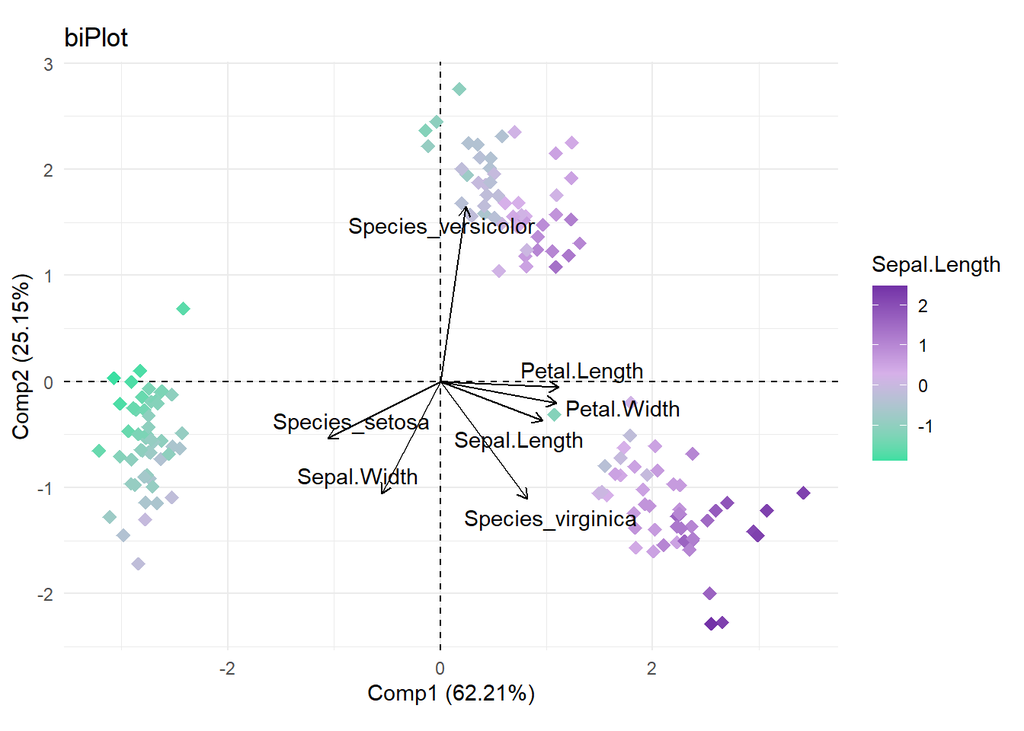

```r
# 4. Biplot: Observations and variables in the same space
pcaPlot(mypca, type = 'biplot', colBy = 'Sepal.Length', labels = c(FALSE, TRUE))
```

The Correlation Plot projects variables onto a unit circle. The proximity of a variable to the circle’s edge indicates how well it is represented by the current components. Arrows pointing in the same direction indicate high positive correlation.

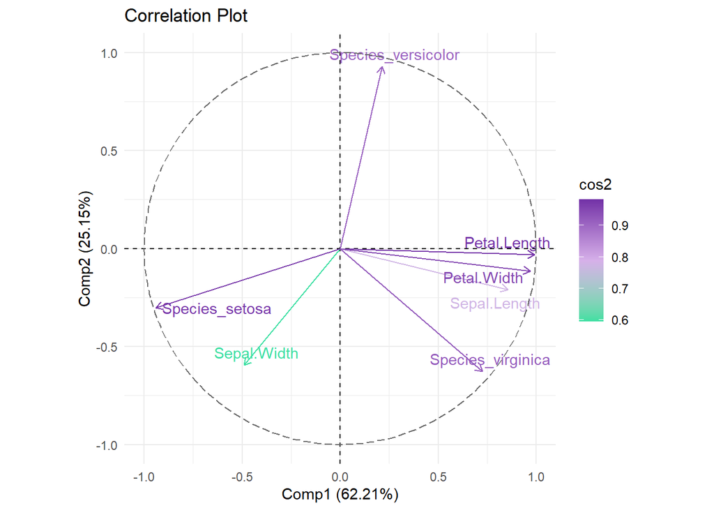

```r
# 5. Correlation Plot: Evaluates variable representation and correlations
pcaPlot(mypca, type = 'corr', shape = 'arrow', colBy = 'cos2', labels = TRUE)
```

Finally, The R2 Plot provides a bar-chart summary of how much variance of each individual variable is captured by the model in each component.

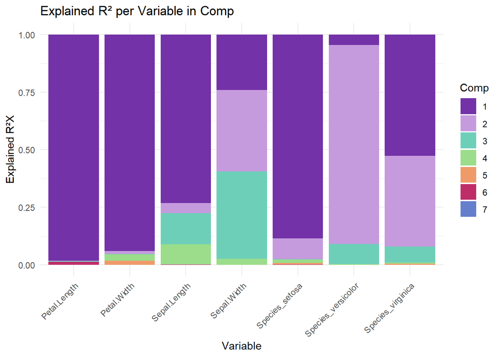

```r
# 6. R2 Plot: Explained variance per individual variable in each component
pcaPlot(mypca, type = 'R2')
```